# **S_9 Informe**

## Índice

1. Tema del estudio / Justificación.
2. Recolección de datos.
3. Información relevante.

## **1. Tema del estudio / Justificación**

### Tema investigado

*Encuesta sobre la Situación de Empleabilidad* | *Encuesta Permanente de Empleo*

(*MAYO - JUNIO - JULIO 2022*)

### Relevancia del estudio

- La importancia de investigar acerca de las características del empleo e ingresos de la población activa en las áreas de Lima Metropolitana y el Callao nos permiten observar su evolución y desarrollo a través del tiempo.

### **Planificación**

```r
remove.packages("rlang")
```

```
Removing package from ‘C:/Users/lesli/AppData/Local/R/win-library/4.2’
```

```r
install.packages("rlang")
```

[output not shown]

```r
library(rlang)
```

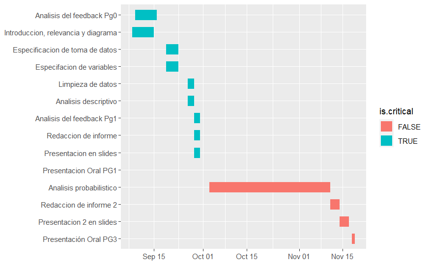

```r
library(reshape2)
library(ggplot2)

tasks <- c("Presentación Oral PG3","Presentacion 2 en slides","Redaccion de informe 2","Analisis probabilistico","Presentacion Oral PG1","Presentacion en slides","Redaccion de informe", "Analisis del feedback Pg1", "Analisis descriptivo","Limpieza de datos","Especifacion de variables","Especificacion de toma de datos","Introduccion, relevancia y diagrama", "Analisis del feedback Pg0")
dfr <- data.frame(
  name        = factor(tasks, levels = tasks),
  start.date  = as.Date(c("2022-11-18","2022-11-14", "2022-11-11", "2022-10-03", "2022-09-30", "2022-09-28", "2022-09-28", "2022-09-28","2022-09-26", "2022-09-26","2022-09-19", "2022-09-19", "2022-09-08", "2022-09-09")),
  end.date    = as.Date(c("2022-11-19", "2022-11-17", "2022-11-14", "2022-11-11","2022-09-30", "2022-09-30", "2022-09-30", "2022-09-30", "2022-09-28", "2022-09-28", "2022-09-23", "2022-09-23", "2022-09-15", "2022-09-16")),
  is.critical = c(FALSE, FALSE, FALSE, FALSE, TRUE, TRUE, TRUE, TRUE, TRUE, TRUE, TRUE, TRUE, TRUE, TRUE)
)
mdfr <- melt(dfr, measure.vars = c("start.date", "end.date"))

ggplot(mdfr, aes(value, name, colour = is.critical)) +
  geom_line(size = 6) +
  xlab(NULL) +
  ylab(NULL)
```

## **2. Recolección de datos**

### Manera de obtención de datos

Toda la información utilizada por el grupo durante el proyecto fue obtenida mediante la búsqueda de una base de datos en internet, con la cual encontramos y rescatamos una fuente del INEI ([Catálogo - Base de Datos](https://www.inei.gob.pe/media/difusion/apps/#p=7)) ([Base de Datos](http://iinei.inei.gob.pe/microdatos/index.htm)).

### ¿Por qué se realizó de esa forma?

Se realizó de esta forma debido a que nuestra profesora nos aconsejó tomar ideas más innovadoras, las cuales puedan ayudarnos a realizar un mejor proyecto de investigación. Además, analizaríamos datos reales del lugar de estudio. De esta forma, optamos por rescatar una base de datos.

### Condiciones y estrategias

La principal condición que debíamos cumplir era conseguir una base de datos que cumpliera mínimo con 200 observaciones. En nuestro caso, conseguimos una con más de 15000 casos, por lo que se nos hizo sencillo cumplir ese requisito.

### POBLACIÓN, MUESTRA Y MUESTREO

Antes que nada, es importante mencionar que esta investigación se viene efectuando desde el año 2001 y esta es dividida por trimestres. 2.2.1. Población determinada Para este estudio, se consideró como población a investigar al conjunto de domicilios particulares y sus ocupantes con residencia habitual situados en las áreas de Lima Metropolitana y Callao. 2.2.2. Tamaño de la muestra En esta fracción de la investigación que hemos tomado (Mayo - Junio - Julio, 2022) se investigaron 4800 viviendas. Cabe resaltar que se estudiaron 1600 viviendas mensuales, las cuales fueron distribuídas en 400 conglomerados donde se seleccionaron 4 residencias. Es relevante señalar que en esta encuesta continua al año se estudian 19200 domicilios particulares. 2.2.2.1. Efectividad de la muestra Como mencionamos anteriormente, la muestra estipulada fue de 4800 viviendas durante el trimestre, sin embargo, la cantidad real de residencias entrevistadas fue de 4406 (91,8%). Esto se puede apreciar en el cuadro a continuación:

[figure not shown]

2.2.3. Tipo de Muestreo

Con el fin de obtener resultados representativos en relación a la población, se seleccionó a la muestra en base a ciertos criterios. Previamente al conjunto muestral elegido, se dividió a la población en estratos socioeconómicos. De esta manera, se determinó que el tipo de muestreo fue probabilístico estratificado, ya que se dividió a la población en segmentos homogéneos basados en su nivel socioeconómico y se seleccionó aleatoriamente los objetos de investigación dentro de estos. Se podría decir lo mismo con los casos encuestados en la muestra, ya que se eligieron 4 viviendas aleatorias en 400 conglomerados de residencias.

### VARIABLES

Variables Cuantitativas:

- Continuas:
  - Ingreso mensual total: Número entero. No negativo
- Discretas:
  - Edad: Cantidad de años completos cumplidos

Variables Cualitativas:

- Ordinales:
  - Nivel educativo aprobado: [Sin Nivel | Inicial | Primaria Incompleta | Primaria Completa | Secundaria Incompleta | Secundaria Completa | Superior No Universitaria Incompleta | Superior No Universitaria Completa | Superior Universitaria Incompleta | Superior Universitaria Completa]
- Nominales:
  - Género: [Hombre | Mujer]
  - Parentesco con el jefe del hogar: [Jefe/Jefa | Esposa(o)/Compañera(o) | Hijo(a)/Hijastro(a) | Yerno/Nuera | Nieto/a | Padres/Suegros | Hermano/a | Otros parientes | Trabajador/a del hogar | Pensionista | Otros No Parientes]
  - Se encuentra ausente del hogar 30 días o más: [Sí | No]
  - Cuenta con un empleo fijo: [Sí | No]
  - Desempeño en su ocupación principal: [Empleador o patrono | Trabajador Independiente | Empleado | Obrero | Trabajador familiar No remunerado | Trabajador del hogar | Otro]
  - ¿Para quién trabajó el entrevistado en su ocupación principal?: [Fuerzas Armadas, Policía Nacional del Perú (militares) | Administración Pública | Empresa Pública | Empresas especiales de servicios (SERVICE) | Empresa o patrono privado | Otro]
  - Cuenta con un negocio propio: [Sí | No]
  - Cantidad de trabajadores de su empresa: [Menos de 100 personas | De 100 a más personas]
  - Realiza horas extra: [Sí | No]
  - Frecuencia de pago/sueldo: [Practicante | Diaria | Semanal | Quincenal | Mensual]
  - Tiene actividad secundaria: [Sí | No]
  - Lengua Materna: [Quechua | Aymara | Otra lengua nativa | Castellano | Portugués | Otra lengua extranjera | ES SORDO MUDO(A) / MUDO(A) | Lengua de señas peruanas]
  - Indicador de condición de actividad: [Ocupado | Desocupado abierto | Desocupado oculto | No PEA]
  - Cultura/Etnia: [Quechua | Aymara | Nativo o indígena de la Amazonía | Negro/Mulato/Zambo/Afro peruano | Blanco | Mestizo | Otro | NO SABE]

## **3. Algunos Datos Relevantes**

- *Sobre el estudio*

Esta investigación se viene efectuando *desde el año 2001* y esta es dividida por trimestres.

- *Población*

Conjunto de domicilios particulares y sus ocupantes con residencia habitual situados en las áreas de Lima Metropolitana y Callao.

- *Muestra*

4800 viviendas (1600 viviendas encuestadas mensualmente).

## **4. Nuestros objetivos**

- Entender la situación de empleo de los pobladores de Lima Metropolitana y Callao, a través de un análisis estadístico riguroso.

## **5. Limpieza de Datos**

1. Primero instalamos y cargamos las librerías `readr` y `dplyr`.

[output not shown]

2. Leemos el archivo que utilizamos, es decir, nuestra base de datos y lo guardamos en la variable `DD`.
3. Los datos están representados por números, por lo cual, cambiaremos a su valor real.
4. Borramos las variables inservibles
5. Cambiamos el nombre de las variables
6. Nos interesa las variables:
   - Sexo
   - Edad
   - Parent.JefeHogar
   - masde30diasAus.
   - NivelEduc.Aprob.
   - EmpleoFijo
   - DesempeñoOcup.
   - NegocioPropio
   - Empleador
   - Cant.Trabajadores
   - RealizaHrsExtra
   - Frec.Pago
   - Act.Secundaria
   - LenguaMaterna
   - CondicionActividad
   - Cultura
   - IngrMensualTot
7. Hacemos una nueva Data Frame con las variables que de verdad nos interesan y lo renombramos

## **6. ¡Resultados!**

### GRÁFICOS

- **PARA LAS VARIABLES NUMÉRICAS:**
- **Variable Edad**

Extremo superior: 98 Extremo inferior: 2 Cuartil inferior: 17 Cuartil superior: 55 Mediana: 35,4

- **Variable Ingreso mensual total**

Mediana: 1723.644 Desviación estándar: 1818.962 Mínimo valor:0 Máximo valor:36100

En este caso, con las modificaciones hechas tenemos los siguientes datos:

Mediana: 1635.879 Desviación estándar: 1436.769 Mínimo valor:0 Máximo valor:10000

Nos interesa relacionar la variable Género con la variable Ingreso Mensual Total

Filtramos el dataframe para no contar los datos perdidos.

- **Variable Empleo Fijo**

- **Variable Frecuencia de Pago**

- **Variable Nivel Educativo Aprobado**

## **Análisis Probabilístico**

### Pregunta 1

- ¿Cuál es la probabilidad de que una persona que tiene secundaria completa tenga empleo fijo?
- Variables aleatorias:
  - Número de personas con secundaria completa
  - Número de personas con empleo fijo

### Pregunta 2

- ¿Cuál es la probabilidad de que una persona que tenga una lengua materna diferente al castellano tenga un ingreso mensual mayor a 1500 la de una persona que hable castellano?
- Variables aleatorias:
  - Número de personas con lengua materna diferente al castellano
  - Número de personas con el castellano de lengua materna
  - Número de personas con un ingreso mensual mayor a 1500

### Pregunta 3

- ¿Cuál es la probabilidad de que una persona, que tiene como empleador a una administración pública, tenga educación superior universitaria completa?
- Variables aleatorias:
  - Número de personas con una administración pública como empleador
  - Número de personas con educación superior universitaria completa

### Pregunta 4

- ¿Cuál es la probabilidad de que un afroperuano tenga como empleador a una empresa privada?(y que su sueldo sea mayor al promedio)
- Variables aleatorias
  - Número de personas de étnia afroperuana
  - Número de personas con una empresa privada como empleador
  - Número de personas con sueldo mayor al promedio

### Pregunta 5

- ¿Cuál es la probabilidad de que una persona de genero femenino tenga un ingreso mensual mayor al promedio del género masculino?
- Variables aleatorias
  - Número de personas de género femenino
  - Número de personas de género masculino

## Distrubucion hipergeométrica

Para erradicar la tasa de desempleo, el Ministerio de Trabajo ha planteado una convocatoria para generar una mayor empleabilidad en el sector público, por lo que se aprueban finalmente a 100 seleccionados entre hombres y mujeres de 30 años. ¿Cuál es la probabilidad de que al menos el 50% de los seleccionados sea mujer menor a 30 años?

r=#mujeres nr=Numero total-r n=100 x>=50

## Distribución binomial

*MEDIA DEL INGRESO MENSUAL*

```r
IngresoMensualT_ <- NDF %>%
  select(IngresoMensualTotal) %>% filter(complete.cases(.)) %>% filter(IngresoMensualTotal <= 10000)
```

$1300 < x < 3970$